# Time Series Analysis on US Tourist Demand after COVID-19

# 1 Introduction

The data of overseas non-resident arrivals to the U.S. was extracted from the U.S. Government website: National Travel & Tourism Office. The data spans from January, 2003 to March, 2020 and its measurement includes all countries except Canada and Mexico. Notice the data set updated on the February and March overseas non-resident arrivals

Section 2 is the data overview and recap of midterm project. Section 3 includes: Pomp modeling and its likelihood estimation.

# 2 SARIMA Model

## 2.1 Summary Results

The trend plot is shown below:

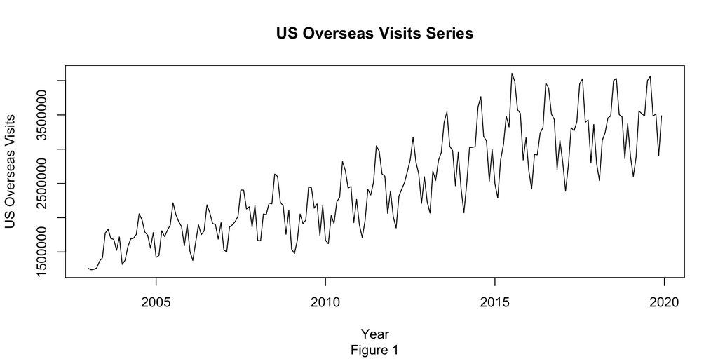

the SARIMA model for non-stationary monthly data $(p, d, q)\times (P, D, Q)_12$ is defined as
$$\phi(B)\Phi(B^{12})((1-B)^d(1-B)^{12})^D
Y_n-\mu)=\psi(B)\Psi(B^{12})\epsilon_n,$$
where $\phi(B)$ and $\Phi(B)$ are polynomials in $B$ of order $p$ and $q$, $psi(B)$ and$\Psi(B)$ polynomials in $B^{12}$ of order $P$ and $Q$, $Y_t$ is the observation at time $t$, $\mu=E[(1-B)^d(1-B)^{12})^D]$ is the mean of the differenced process, and $\epsilon_t$ is the white noise with mean $0$ and constant variance $\sigma^2.$

```
## Series: log(Visits_ts)
## ARIMA(1,0,3)(1,1,1)[12] with drift
##
## Coefficients:
##          ar1      ma1     ma2     ma3     sar1     sma1   drift
##       0.7815  -0.4519  0.1894  0.3075  -0.1417  -0.6706  0.0042
## s.e.  0.0632   0.0816  0.0722  0.0887   0.1150   0.0979  0.0004
##
## sigma^2 estimated as 0.002016:  log likelihood=322.03
## AIC=-628.05   AICc=-627.27   BIC=-601.99
```

## 2.2 Diagnostic Plots and Prediction

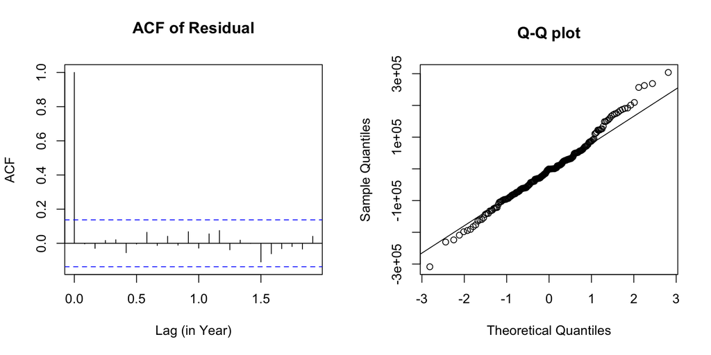

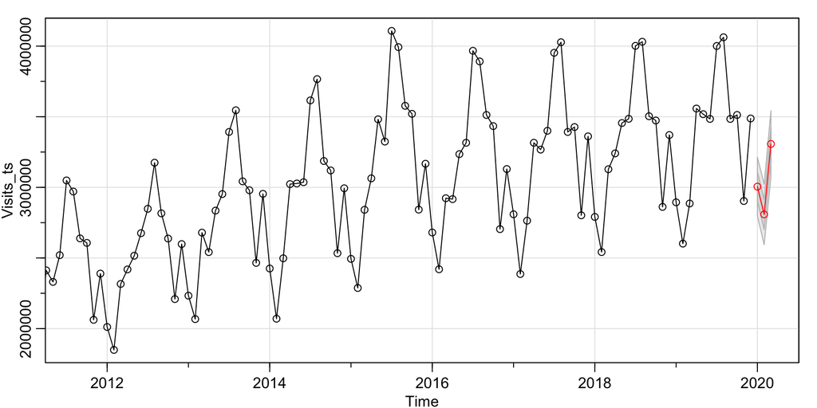

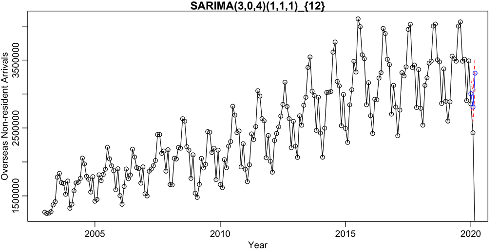

# 3 POMP Modeling

## 3.1 Geometric Brownian Motionl

Rprocess is based on geometric brownian motion (GRM) model of which the logarithm of randomly varying quantity a Brownian motion. It has two state variables: $N$ and $\epsilon$ and three parameters: $\mu$ (drift), $\sigma$. and $\delta$ (volatility) (Brewer et al. 2016). The differential equation is

$$dN=\mu Ndt+\delta N \epsilon \sqrt{dt}$$
$$d log(N)=(\mu-\frac{\delta^2}{2}) dt+\delta \epsilon
\sqrt{dt}$$
where $N$ is the arrivals in each month and $\epsilon$ is a random draw from $N(0,\sigma)$. Solving the above equation, we can get
$$N_{t+\Delta t}=N_t \exp((\mu-\frac{\delta^2}{2}) \Delta
t+\delta \epsilon \sqrt{\Delta t})$$
,
$$N_{t+1}=N_t \exp((\mu-\frac{\delta^2}{2}) \frac{1}{n}+
\frac{\delta}{\sqrt{n}} \epsilon)$$
, where $n$ represents the number of months in a year.

## 3.2 Building a POMP Model

We first to take log to detrend data for pomp modeling.

We first define variables in the pomp object and the initial value of $N$ and $\epsilon=0$ are set to be 10 and rpois(1). Rmeasure is defined as random draw from a normal distribution with mean 0 and variance $N$.

```r
pop_statenames = c("N", "e")
pop_paramnames = c("mu","delta","sigma")

stochStep <- Csnippet("e = rnorm(0,sigma);
                  N = N*exp((mu-delta*delta/2)/12+delta/sqrt(12)*e);")

initlz <- Csnippet("N=10;e=rpois(1);")
dmeas <- Csnippet("lik = dnorm(Arrivals,0,N,give_log);")
rmeas <- Csnippet("Arrivals = rnorm(0,N);")
```

```r
pomp(data = tour[,1:2],
     times="Month",
     t0=0,
     rprocess=discrete_time(step.fun=stochStep,delta.t=1),
     rinit=initlz,
     rmeasure = rmeas, dmeasure = dmeas,
     statenames=pop_statenames,
     paramnames=pop_paramnames,
     partrans=parameter_trans(
      log=c("mu","sigma"),
      logit="delta")
     ) -> pop_pomp
```

## 3.3 Log-likehood Slice and Surface

Next, we would like to investigate the likelihood surface of our model by construct a geometric surface and see how the log-likelihood changes with parameters.

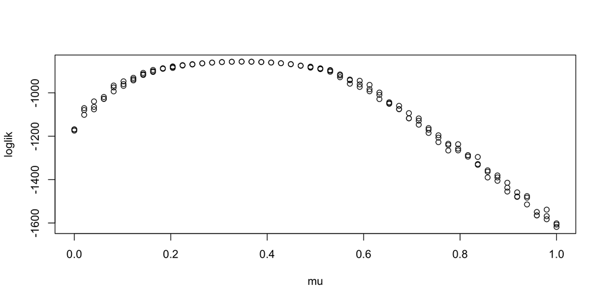

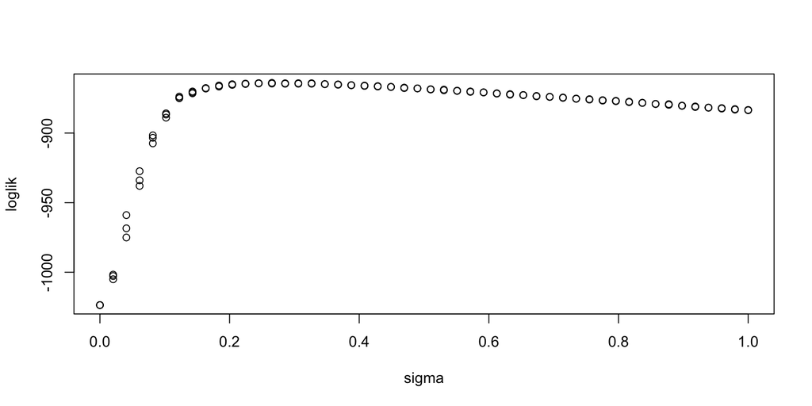

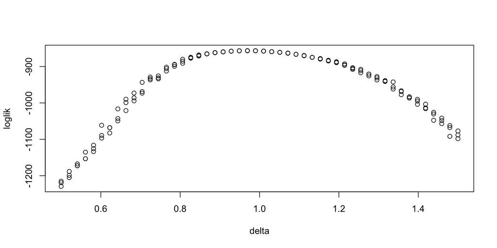

From log-likelihood plots, we can see log-likelihood is maximized at around $\mu=0.4$ along $\mu$ direction, $\delta=1$ along $\delta$ direction, and $\sigma=0.3$ along $\sigma$ direction.

```
##  [1] -885.0366 -892.9376 -892.6783 -888.0243 -898.2768 -886.6809 -884.8339
##  [8] -894.2333 -888.8317 -888.1283
```

```
##                        se
## -886.4081522    0.6887519
```

## 3.4 Maximizing the Likelihood Using the Particle Filter

### 3.4.1 Local Search

We need to build new pomp object before conducting a local maximum likelihood search around previously identified MLE.

```
##    Min. 1st Qu.  Median    Mean 3rd Qu.    Max.
##  -856.8  -856.5  -856.4  -856.5  -856.4  -856.2
```

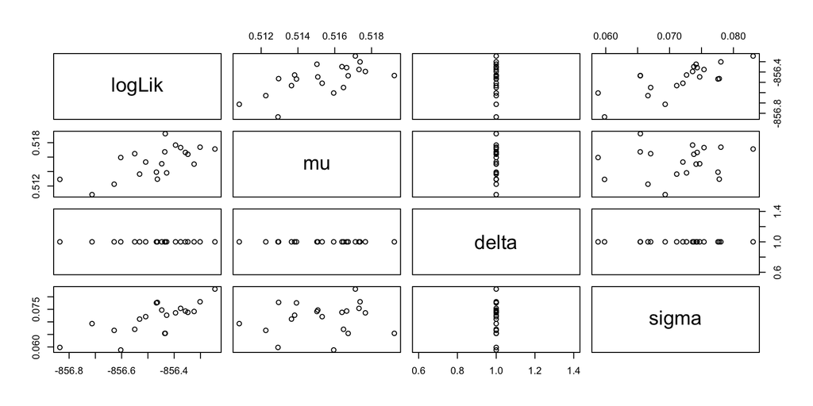

The maximum loh-likelihood result from local search is -856.2 and the scatter plots shows the likelihood surface in the neighborhood of given point estimates.

### 3.4.3 Global Search

Next, we would like to conduct a global search of log-likelihood. The parameter box is given below:

```r
pop_box <- rbind(mu=c(0, 1),
                 delta=c(0,3),
                 sigma=c(0,3))
```

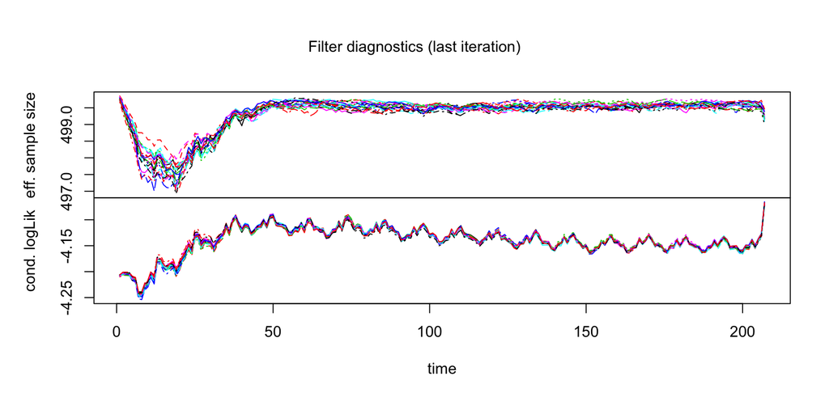

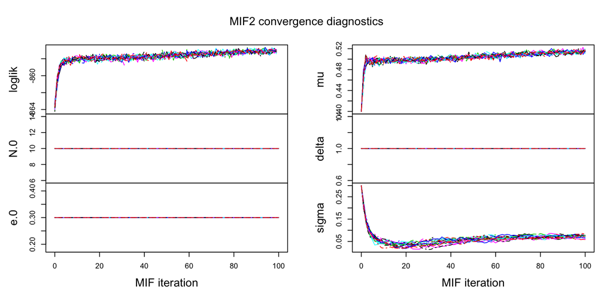

Both local search and global search give similar max log-likelihood. From the POMP diagnostics plot, we can see overall parameters converges but there is some Monte Carlo variation. $\hat \mu$, $\hat \delta$, and $\hat \sigma$ converge to their maximum-likelihood estimates.

# 4 Conclusion

# 5 References

[1] Data: https://travel.trade.gov/view/m-2017-I-001/index.asp

[2] Coronavirus: https://www.cdc.gov/coronavirus/2019-ncov/about/transmission.html

[3] Avdiu, K. Brownian Motion & Geometric Brownian Motion. Retrieved April 26, 2018, from http://homepage.univie.ac.at/kujtim.avdiu/dateien/BrownianMotion.pdf.

[4] Previous Project: https://ionides.github.io/531w18/final_project/3/final.html#geometric-brownian-motion

[5] Lecture notes.